# The basics of plotting in R

## Simple plots

The most straightforward way to make a plot is to use it in the form

```r
plot(x, y)
```

where `x` are the *independent* variables and `y` are the *dependent* variables. The “formula” notation will also work (which is consistent with other R functions, like for fitting models), and

```r
plot(y ~ x)
```

will produce the same result. For some examples, we can use the built-in dataset `iris` (but explicitly pass certain columns), or just make up some of our own data.

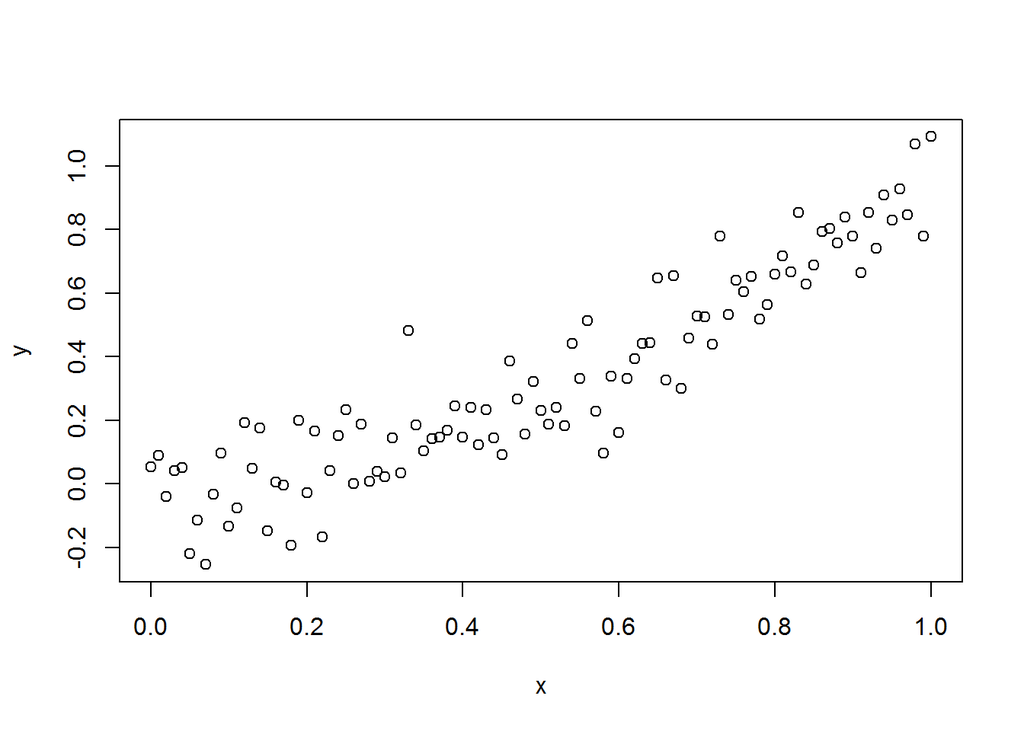

```r
x <- seq(0, 1, by=0.01)
y <- x^2 + rnorm(x, sd=0.1)
plot(x, y)
```

By default, the `type=` argument is set to `"p"`, which stands for “points”. Other options are:

- “p” for points,
- “l” for lines,
- “b” for both,
- “c” for the lines part alone of “b”,
- “o” for both ‘overplotted’,
- “h” for ‘histogram’ like (or ‘high-density’) vertical lines,
- “s” for stair steps,
- “S” for other steps, see ‘Details’ below,
- “n” for no plotting.

To plot with lines do:

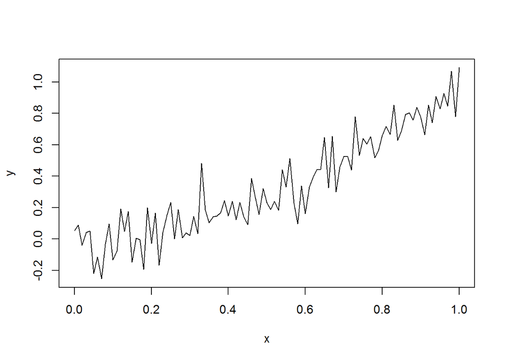

```r
plot(x, y, type='l')
```

We can change some things about the plot using some of the most-used arguments, including x/y labels (`xlab=`/`ylab=`) and the plotting character (`pch`).

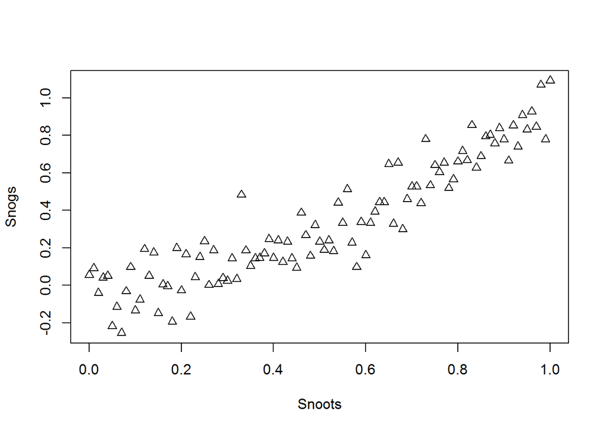

```r
plot(x, y, xlab='Snoots', ylab='Snogs', pch=2)
```

For documentation of the different `pch` that are available, see `?pch`. Basically, they are identified by the integers between 1 and 25, and we can view them by making a simple plot:

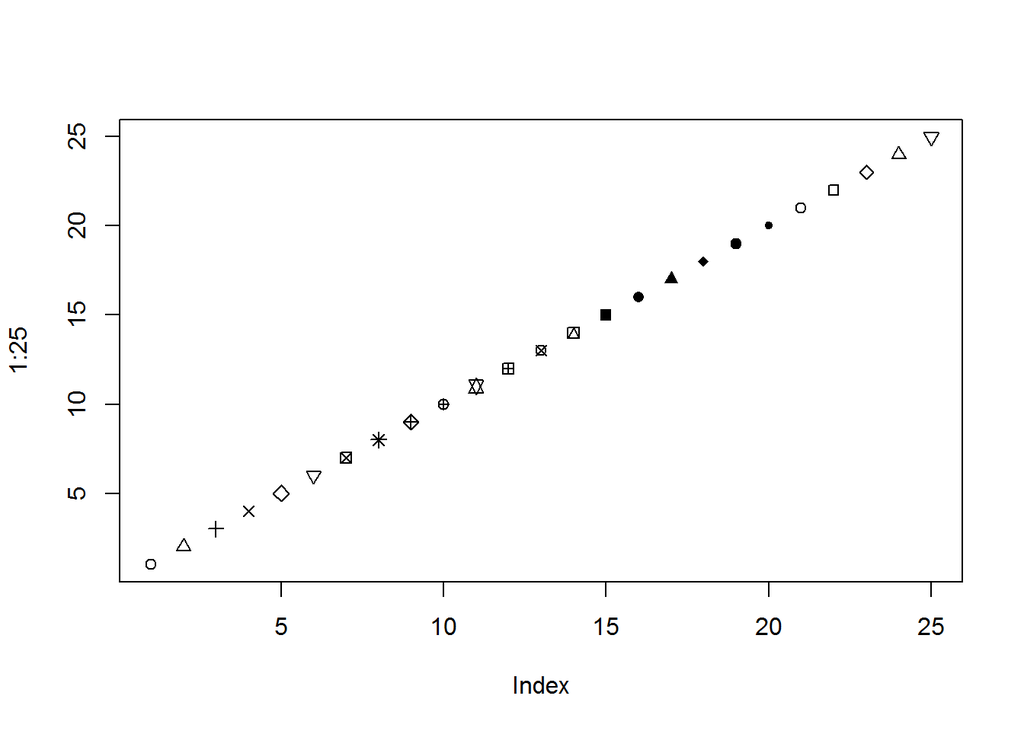

```r
plot(1:25, pch=1:25)
```

Want a title? Easy – you can either use the `main=` argument in plot, or the separate `title()` function to add it after:

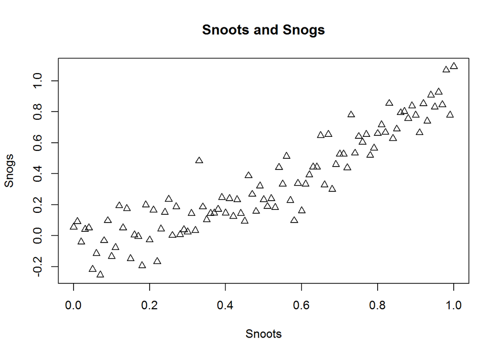

```r
plot(x, y, xlab='Snoots', ylab='Snogs', pch=2, main='Snoots and Snogs')
```

```r
## title('Snoots and Snogs')
```

If you’re plotting lines, and you want to change aspects of the line, you can do as:

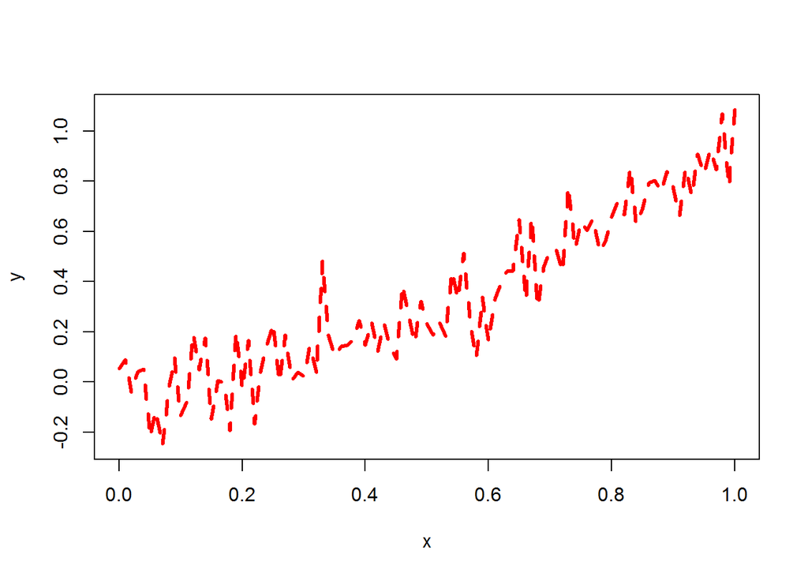

```r
plot(x, y, type='l',
     lwd=3, #line width
     lty=2, #line type
     col='red' #color, obviously
)
```

For a complete (and slightly overwhelming) overview of all the `par`ameters that you can change in plots, do `?par`. If you call `par` with no arguments, it returns a list of all the currently set graphics parameters:

```r
str(par())
```

```
## List of 72
##  $ xlog     : logi FALSE
##  $ ylog     : logi FALSE
##  $ adj      : num 0.5
##  $ ann      : logi TRUE
##  $ ask      : logi FALSE
##  $ bg       : chr "white"
##  $ bty      : chr "o"
##  $ cex      : num 1
##  $ cex.axis : num 1
##  $ cex.lab  : num 1
##  $ cex.main : num 1.2
##  $ cex.sub  : num 1
##  $ cin      : num [1:2] 0.15 0.2
##  $ col      : chr "black"
```

[output cut: 58 more lines]

### Adding to plots

You’ll notice that calling the `plot()` function always creates a *new* plot – if you want to *add* things to a plot, you should use the `points()` and `lines()` functions:

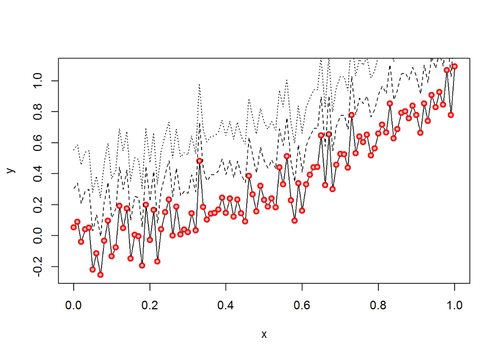

```r
plot(x, y, type='l')
points(x, y, pch=21, col=2, bg='grey', lwd=2)
lines(x, y + 0.25, lty=2)
lines(x, y + 0.5, lty=3)
```

# Multipanel plots

To make plots with more than one panel (like the default plot for data frames), we can use the `par()` function to set up plot parameters *before* calling the `plot()` function. The parameter we want for this is `mfrow`, which indicates we want a multi-figure plot, filled *row-wise*. An equivalent option is `mfcol`, which fills the panels *column-wise*. To make a plot with 2 rows and 3 columns, we first set the `par` with `par(mfrow=c(2, 3))`. Then each new `plot()` command will fill the next panel:

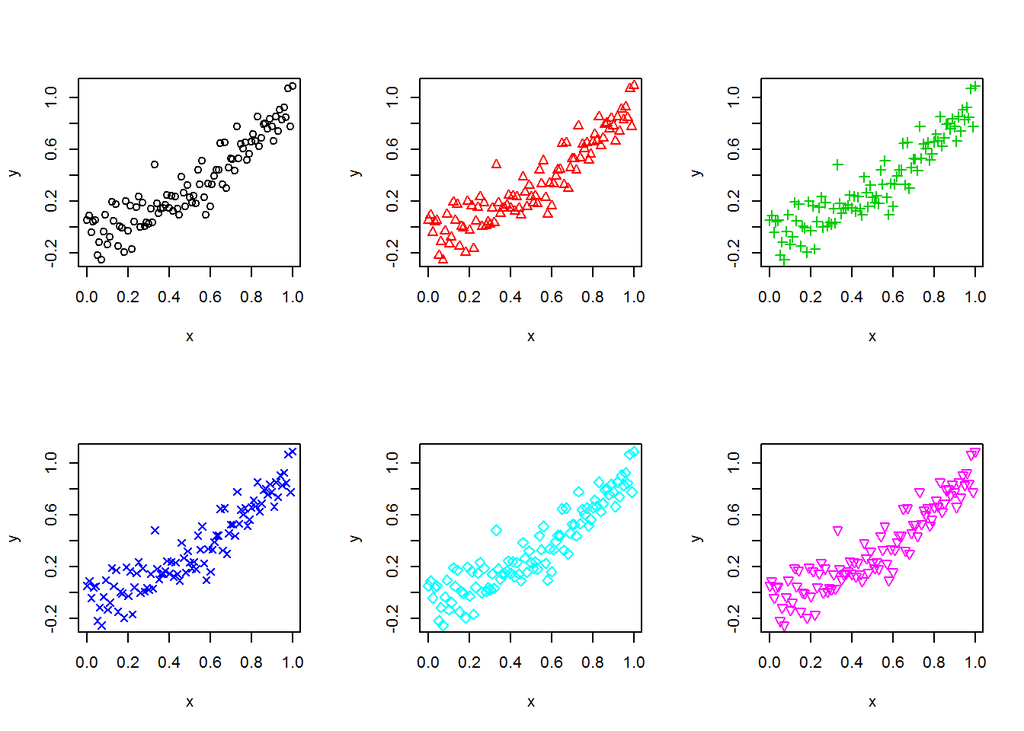

```r
par(mfrow=c(2, 3))
plot(x, y)
plot(x, y, pch=2, col=2)
plot(x, y, pch=3, col=3)
plot(x, y, pch=4, col=4)
plot(x, y, pch=5, col=5)
plot(x, y, pch=6, col=6)
```

Note that the above example would be a nice demonstration of a `for` loop in R:

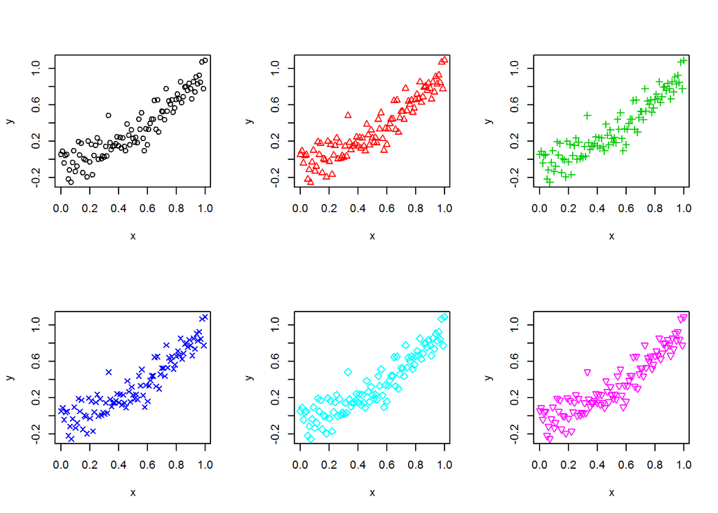

```r
par(mfrow=c(2, 3))
for (i in 1:6) {
    plot(x, y, pch=i, col=i)
}
```

# Adjusting margins

R makes pretty nice looking plots by default – but one criticism that is common is that there tends to be a lot of whitespace. For single plots this isn’t a big deal, but when combining subplots it produces a lot of waste.

To adjust the margins, we again use the `par()` function, but now focus on the two parameters: `mar` and `mgp`.

The `mar` parameter is a vector that gives the margin widths around the plot (in units of *lines*), like: `c(bottom, lhs, top, rhs)`.

The `mgp` parameter is a 3 element vector that describes where margin “stuff” should go – the 3 elements correspond to the line number for:

1. axis labels,
2. tick labels, and
3. ticks

Typical default values for `mar` and `mgp` are:

```r
par('mar')
```

```
## [1] 5.1 4.1 4.1 2.1
```

```r
par('mgp')
```

```
## [1] 3 1 0
```

Let’s use the 6 panel plot from above, but try and tighten things up. First I’ll change only the `mar`:

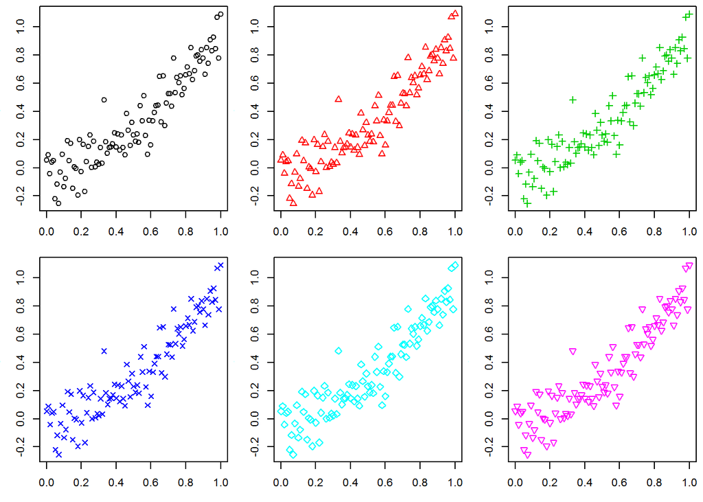

```r
par(mfrow=c(2, 3),
    mar=c(3, 3, 0.5, 0.5))
for (i in 1:6) {
    plot(x, y, pch=i, col=i)
}
```

That looks better, but notice how the axis labels are gone! We can fix that with `mgp`:

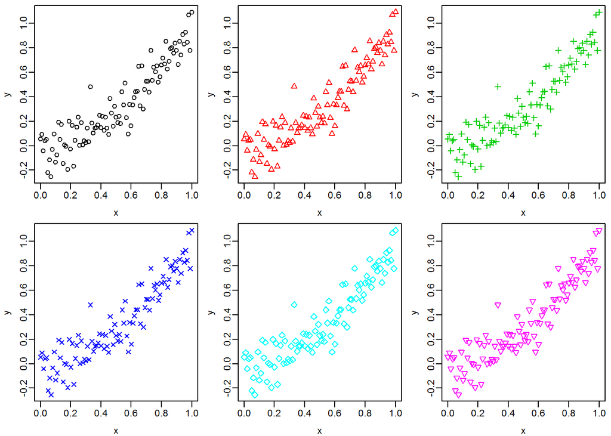

```r
par(mfrow=c(2, 3),
    mar=c(3, 3, 0.5, 0.5),
    mgp=c(2, 0.5, 0))
for (i in 1:6) {
    plot(x, y, pch=i, col=i)
}
```

# Plot legends

Easiest is probably to illustrate the use of legend with some examples. Basically, make the plot, and then add the elements (and their particulars) to the legend arguments to identify the different features:

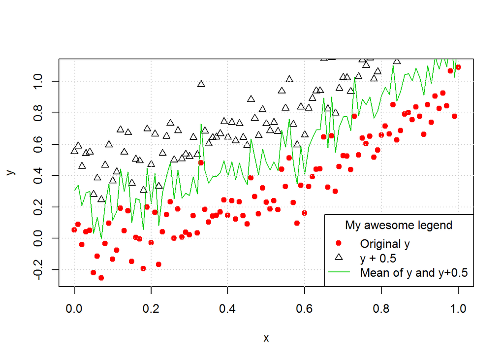

```r
plot(x, y, pch=19, col=2)
points(x, y + 0.5, pch=2)
lines(x, (y + y+0.5)/2, pch=3, col=3)
grid() # add grid lines
legend('bottomright',
       legend=c('Original y',
                'y + 0.5',
                'Mean of y and y+0.5'),
       pch=c(19, 2, NA),  # Note use of NA for the "line" feature
       lty=c(NA, NA, 1),  # Note use of NA for the "points" features
       col=c(2, 1, 3),
       title='My awesome legend')
```

# Other useful plot types

- **Histograms:** Histograms are useful in statistical analyses, and can be done using the `hist()` function:

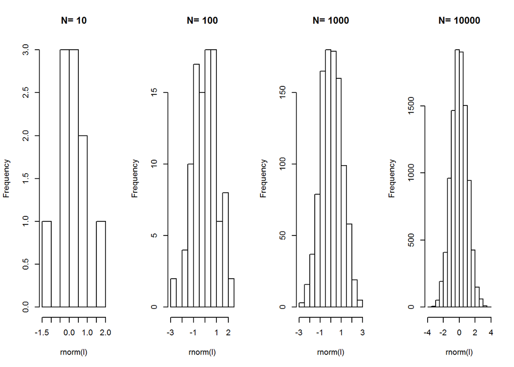

```r
len <- c(10, 100, 1000, 10000)
par(mfrow=c(1, length(len)))
for (l in len) {
    hist(rnorm(l), main=paste("N=", l))
}
```

- **Boxplots**: boxplots are another common statistical summary plot, which can be made with the `boxplot()` function. Boxplots are optimized for tabular data (e.g. data frames), and so generally behave sensibly with a minimum of arguments. For example, just doing a `boxplot()` of a data frame gives a summary for each of the columns:

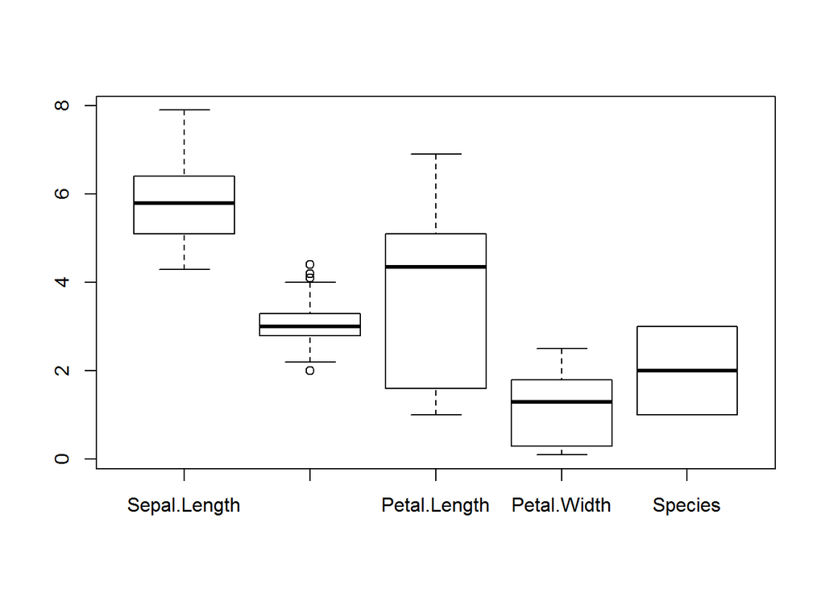

```r
boxplot(iris)
```

But we can also use some of the columns (remember how the `Species` column is a “factor”?) to plot different summaries:

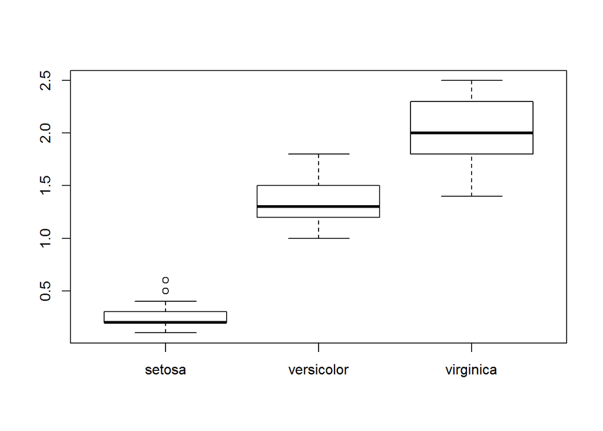

```r
boxplot(Petal.Width ~ Species, data=iris)
```